# MATH2349 Semester 2, 2018

Assignment 3

Nicholas Pennell, s3588789

## Required packages

```r
  library(dplyr) # Data wrangling
  library(tidyr) # Data wrangling
  library(knitr) # Tables
  library(kableExtra) # Tables
  library(readr) # Reading data
  library(lubridate) # For Dates
```

## Data

The data is from the [Lahman Baseball Database](http://www.seanlahman.com/). The database is made and maintained by reporter Sean Lahman. I got the data from [Kaggle](https://www.kaggle.com/freshrenzo/lahmanbaseballdatabase)

To keep things down in size I’m just going to be looking at just players that have won awards.

The `csv` files are all read in with `read_csv` from `readr` the merged using `dplyr` join functions. One column was removed. The first 50 obsevations are shown in table.

```r
# Players that have made the Hall of Fame
  awards <- read_csv("C:/RMIT/Data Preprocessing/Assignment 3/Data/AwardsPlayers.csv")
# Batting Stats of players for a season
  batting <- read_csv("C:/RMIT/Data Preprocessing/Assignment 3/Data/Batting.csv")
# Merging
  baseball <- batting %>% inner_join(awards, by = c("playerID", "yearID", "lgID"))
# Removing unwated stint
  baseball <- baseball[, -c(3)]
# Data Table Sample
  baseball[1:50, ]
```

| playerID | yearID | teamID | lgID | G | G_batting | AB | R | H | 2B | 3B | HR | RBI | SB | CS | BB | SO | IBB | HBP | SH | SF | GIDP | G_old | awardID | tie | notes |
| --- | --- | --- | --- | --- | --- | --- | --- | --- | --- | --- | --- | --- | --- | --- | --- | --- | --- | --- | --- | --- | --- | --- | --- | --- | --- |
| aaronha01 | 1956 | ML1 | NL | 153 | 153 | 609 | 106 | 200 | 34 | 14 | 26 | 92 | 2 | 4 | 37 | 54 | 6 | 2 | 5 | 7 | 21 | 153 | TSN Player of the Year | NA | NA |
| aaronha01 | 1957 | ML1 | NL | 151 | 151 | 615 | 118 | 198 | 27 | 6 | 44 | 132 | 1 | 1 | 57 | 58 | 15 | 0 | 0 | 3 | 13 | 151 | Most Valuable Player | NA | NA |
| aaronha01 | 1958 | ML1 | NL | 153 | 153 | 601 | 109 | 196 | 34 | 4 | 30 | 95 | 4 | 1 | 59 | 49 | 16 | 1 | 0 | 3 | 21 | 153 | Gold Glove | NA | RF |
| aaronha01 | 1959 | ML1 | NL | 154 | 154 | 629 | 116 | 223 | 46 | 7 | 39 | 123 | 8 | 0 | 51 | 54 | 17 | 4 | 0 | 9 | 19 | 154 | Gold Glove | NA | RF |
| aaronha01 | 1960 | ML1 | NL | 153 | 153 | 590 | 102 | 172 | 20 | 11 | 40 | 126 | 16 | 7 | 60 | 63 | 13 | 2 | 0 | 12 | 8 | 153 | Gold Glove | NA | RF |
| aaronha01 | 1963 | ML1 | NL | 161 | 161 | 631 | 121 | 201 | 29 | 4 | 44 | 130 | 31 | 5 | 78 | 94 | 18 | 0 | 0 | 5 | 11 | 161 | TSN Player of the Year | NA | NA |
| aaronha01 | 1963 | ML1 | NL | 161 | 161 | 631 | 121 | 201 | 29 | 4 | 44 | 130 | 31 | 5 | 78 | 94 | 18 | 0 | 0 | 5 | 11 | 161 | TSN All-Star | NA | OF |
| aaronha01 | 1965 | ML1 | NL | 150 | 150 | 570 | 109 | 181 | 40 | 1 | 32 | 89 | 24 | 4 | 60 | 81 | 10 | 1 | 0 | 8 | 15 | 150 | TSN All-Star | NA | OF |
| aaronha01 | 1967 | ATL | NL | 155 | 155 | 600 | 113 | 184 | 37 | 3 | 39 | 109 | 17 | 6 | 63 | 97 | 19 | 0 | 0 | 6 | 11 | 155 | TSN All-Star | NA | OF |
| aaronha01 | 1969 | ATL | NL | 147 | 147 | 547 | 100 | 164 | 30 | 3 | 44 | 97 | 9 | 10 | 87 | 47 | 19 | 2 | 0 | 3 | 14 | 147 | TSN All-Star | NA | OF |

[output cut: 40 more lines]

- List of Varibles:
  - `playerID`, Player ID code
  - `yearID`, Year
  - `teamID`, Team ID code
  - `lgID`, League
  - `G`, Games played that year
  - `G_batting`, Games played as a batter that year
  - `AB`, At bats that year
  - `R`, Runs
  - `H`, Hits
  - `2B`, Doubles
  - `3b`, Triples
  - `HR`, Homeruns
  - `RBI`, Runs Batted In
  - `SB`, Stolen Bases
  - `CS`, Caught Stealing
  - `BB`, Base on Balls
  - `SO`, Strikeouts
  - `IBB`, Intentional walks
  - `HBP`, Hit by pitch
  - `SH`, Sacrifice hits
  - `SF`, Sacrifice flies
  - `GIDP`, Grounded into double plays
  - `G_old`, Old version of games (deprecated)
  - `awardId`, Name of award won
  - `tie`, Award was a tie
  - `notes`, Notes about the award

## Understand

Looked at the type of each varible with `sapply()` and `class()`. Then used a fucntion found on [Stack Overflow](https://stackoverflow.com/questions/11261399/function-for-converting-dataframe-column-type). The function is used to change the class of multiple variables at one time.

Then some levels in `awardID` where changed to more simple names.

```r
# Looking at class of varibles
  sapply(baseball, class)
```

```
   playerID      yearID      teamID        lgID           G   G_batting          AB           R
"character"   "integer" "character" "character"   "integer"   "integer"   "integer"   "integer"
          H          2B          3B          HR         RBI          SB          CS          BB
  "integer"   "integer"   "integer"   "integer"   "integer"   "integer"   "integer"   "integer"
         SO         IBB         HBP          SH          SF        GIDP       G_old     awardID
  "integer"   "integer"   "integer"   "integer"   "integer"   "integer"   "integer" "character"
        tie       notes
"character" "character"
```

```r
# Changing class of varibles
  # Function (from stack overflow)
    convert.magic <- function(obj, type)
    {
      FUN1 <- switch(type,
                     character = as.character,
                     numeric = as.numeric,
                     factor = as.factor)
      out <- lapply(obj, FUN1)
      as.data.frame(out)
    }
  # Using function
    # chaning to factor
      baseball[, c(1:4,24)] <-
        convert.magic(baseball[, c(1:4, 24)], "factor")
    # chaning to logical
      baseball$tie <- ifelse(is.na(baseball$tie), FALSE, TRUE)
  # checking
    sapply(baseball, class)
```

```
   playerID      yearID      teamID        lgID           G   G_batting          AB           R
   "factor"    "factor"    "factor"    "factor"   "integer"   "integer"   "integer"   "integer"
          H          2B          3B          HR         RBI          SB          CS          BB
  "integer"   "integer"   "integer"   "integer"   "integer"   "integer"   "integer"   "integer"
         SO         IBB         HBP          SH          SF        GIDP       G_old     awardID
  "integer"   "integer"   "integer"   "integer"   "integer"   "integer"   "integer"    "factor"
        tie       notes
  "logical" "character"
```

```r
# relabeling
  # Current level names
    award.names <- levels(baseball$awardID)
  # Creating new names for some awards
    new.award.names <- award.names
    new.award.names[3] <- "Postseason MVP"
    new.award.names[6] <- "Best Pitcher"
    new.award.names[7] <- "Best Fielder At Postion"
    new.award.names[8] <- "Best Hitter"
    new.award.names[13] <- "Best Relief Pitcher"
    new.award.names[15] <- "Best Offensive Player At Position"

  # Renaming Levels
    baseball <- baseball %>% mutate(awardID = factor(awardID, levels = award.names,
                                                     labels =  new.award.names))
  # check
    levels(baseball$awardID)
```

```
 [1] "ALCS MVP"                          "All-Star Game MVP"
 [3] "Postseason MVP"                    "Baseball Magazine All-Star"
 [5] "Comeback Player of the Year"       "Best Pitcher"
 [7] "Best Fielder At Postion"           "Best Hitter"
 [9] "Most Valuable Player"              "NLCS MVP"
[11] "Pitching Triple Crown"             "Roberto Clemente Award"
[13] "Best Relief Pitcher"               "Rookie of the Year"
[15] "Best Offensive Player At Position" "Triple Crown"
[17] "TSN All-Star"                      "TSN Fireman of the Year"
[19] "TSN Guide MVP"                     "TSN Pitcher of the Year"
[21] "TSN Player of the Year"            "TSN Reliever of the Year"
```

## Tidy & Manipulate Data I

The three main tidy Data Principles:

1. Each variable must have its own column.
2. Each observation must have its own row.
3. Each value must have its own cell.

All three of these principles are alredy meet.

## Tidy & Manipulate Data II

Created 3 new varibles,

- `batting average (BA)`, is the number of hits dived by the number of at bats
- `On Base Percentage (OBP)`, is how frequently a batter reaches base
- `Slugging Percentage (SLP)`, is a measure of a batters productivity  
  Also added `1B` to use in `SLP`, if the player is a pitcher or not, for futer use. Then a sample table.

```r
# creating batting average (BA), On Base Percentage (OBP) and Slugging Percentage (SLP)
  # BA (hits/At Bats)
    baseball$BA <- baseball$H/baseball$AB
  # OBP ((H+BB+HBP)/(H+BB+HBP+SF))
    baseball$OBP <- (baseball$H + baseball$BB + baseball$HBP)/
      (baseball$H + baseball$BB + baseball$HBP + baseball$SF)
  # SLP ((1+2*2B+3*3B+4*HR)/AB)
    # Adding 1b hits
      baseball$`1B` <- baseball$H - baseball$`2B` - baseball$`3B` - baseball$HR

    baseball$SLP <- (baseball$`1B` + 2*baseball$`2B` + 3*baseball$`3B` + 4*baseball$HR)/baseball$AB
  # Adding Pitches
    pitcher.notes <- pitcher.notes <- c("P", "LHP", "RHP", "Rp", "SP")
    baseball$pitcher <- ifelse(grepl("Pitcher", baseball$awardID) == TRUE | baseball$G_batting == 0 |
                                 baseball$AB == 0 | baseball$notes %in% pitcher.notes,
                           TRUE, FALSE)

# sample table with new varibles
  baseball[1:50, ]
```

| playerID | yearID | teamID | lgID | G | G_batting | AB | R | H | 2B | 3B | HR | RBI | SB | CS | BB | SO | IBB | HBP | SH | SF | GIDP | G_old | awardID | tie | notes | BA | OBP | 1B | SLP | … |
| --- | --- | --- | --- | --- | --- | --- | --- | --- | --- | --- | --- | --- | --- | --- | --- | --- | --- | --- | --- | --- | --- | --- | --- | --- | --- | --- | --- | --- | --- | --- |
| aaronha01 | 1956 | ML1 | NL | 153 | 153 | 609 | 106 | 200 | 34 | 14 | 26 | 92 | 2 | 4 | 37 | 54 | 6 | 2 | 5 | 7 | 21 | 153 | TSN Player of the Year | FALSE | NA | 0.32840722 | 0.9715447 | 126 | 0.55829228 | … |
| aaronha01 | 1957 | ML1 | NL | 151 | 151 | 615 | 118 | 198 | 27 | 6 | 44 | 132 | 1 | 1 | 57 | 58 | 15 | 0 | 0 | 3 | 13 | 151 | Most Valuable Player | FALSE | NA | 0.32195122 | 0.9883721 | 121 | 0.60000000 | … |
| aaronha01 | 1958 | ML1 | NL | 153 | 153 | 601 | 109 | 196 | 34 | 4 | 30 | 95 | 4 | 1 | 59 | 49 | 16 | 1 | 0 | 3 | 21 | 153 | Best Fielder At Postion | FALSE | RF | 0.32612313 | 0.9884170 | 128 | 0.54575707 | … |
| aaronha01 | 1959 | ML1 | NL | 154 | 154 | 629 | 116 | 223 | 46 | 7 | 39 | 123 | 8 | 0 | 51 | 54 | 17 | 4 | 0 | 9 | 19 | 154 | Best Fielder At Postion | FALSE | RF | 0.35453100 | 0.9686411 | 131 | 0.63593005 | … |
| aaronha01 | 1960 | ML1 | NL | 153 | 153 | 590 | 102 | 172 | 20 | 11 | 40 | 126 | 16 | 7 | 60 | 63 | 13 | 2 | 0 | 12 | 8 | 153 | Best Fielder At Postion | FALSE | RF | 0.29152542 | 0.9512195 | 101 | 0.56610169 | … |
| aaronha01 | 1963 | ML1 | NL | 161 | 161 | 631 | 121 | 201 | 29 | 4 | 44 | 130 | 31 | 5 | 78 | 94 | 18 | 0 | 0 | 5 | 11 | 161 | TSN Player of the Year | FALSE | NA | 0.31854200 | 0.9823944 | 124 | 0.58637084 | … |
| aaronha01 | 1963 | ML1 | NL | 161 | 161 | 631 | 121 | 201 | 29 | 4 | 44 | 130 | 31 | 5 | 78 | 94 | 18 | 0 | 0 | 5 | 11 | 161 | TSN All-Star | FALSE | OF | 0.31854200 | 0.9823944 | 124 | 0.58637084 | … |
| aaronha01 | 1965 | ML1 | NL | 150 | 150 | 570 | 109 | 181 | 40 | 1 | 32 | 89 | 24 | 4 | 60 | 81 | 10 | 1 | 0 | 8 | 15 | 150 | TSN All-Star | FALSE | OF | 0.31754386 | 0.9680000 | 108 | 0.55964912 | … |
| aaronha01 | 1967 | ATL | NL | 155 | 155 | 600 | 113 | 184 | 37 | 3 | 39 | 109 | 17 | 6 | 63 | 97 | 19 | 0 | 0 | 6 | 11 | 155 | TSN All-Star | FALSE | OF | 0.30666667 | 0.9762846 | 105 | 0.57333333 | … |
| aaronha01 | 1969 | ATL | NL | 147 | 147 | 547 | 100 | 164 | 30 | 3 | 44 | 97 | 9 | 10 | 87 | 47 | 19 | 2 | 0 | 3 | 14 | 147 | TSN All-Star | FALSE | OF | 0.29981718 | 0.9882812 | 87 | 0.60694698 | … |

[output cut: 40 more lines]

```r
NA
```

## Scan I

An important note for baseball date is that not all stats have been reocred, as some stats are only being recored in more recent years.

So with the missing `SO` where replaced with the mean and then a complete cases was taken.

```r
# Percent of Missing Vaules by Varible
  baseball %>% summarise_each(funs(sum(is.na(.))))
```

```
`summarise_each()` is deprecated.
Use `summarise_all()`, `summarise_at()` or `summarise_if()` instead.
To map `funs` over all variables, use `summarise_all()`
```

| playerID | yearID | teamID | lgID | G | G_batting | AB | R | H | 2B | 3B | HR | RBI | SB | CS | BB | SO | IBB | HBP | SH | SF | GIDP | G_old | awardID | tie | notes | BA | OBP | 1B | SLP | … |
| --- | --- | --- | --- | --- | --- | --- | --- | --- | --- | --- | --- | --- | --- | --- | --- | --- | --- | --- | --- | --- | --- | --- | --- | --- | --- | --- | --- | --- | --- | --- |
| 0 | 0 | 0 | 0 | 0 | 55 | 131 | 131 | 131 | 131 | 131 | 131 | 131 | 134 | 747 | 131 | 238 | 1336 | 134 | 140 | 1328 | 871 | 166 | 0 | 0 | 1016 | 259 | 1530 | 131 | 259 | … |

```r
# Excluding Pitchers and NA
  baseball <- baseball %>% filter(pitcher == FALSE)
# Remaning Missing Vaules by Varible
  baseball %>% summarise_each(funs(sum(is.na(.))))
```

```
`summarise_each()` is deprecated.
Use `summarise_all()`, `summarise_at()` or `summarise_if()` instead.
To map `funs` over all variables, use `summarise_all()`
```

| playerID | yearID | teamID | lgID | G | G_batting | AB | R | H | 2B | 3B | HR | RBI | SB | CS | BB | SO | IBB | HBP | SH | SF | GIDP | G_old | awardID | tie | notes | BA | OBP | 1B | SLP | … |
| --- | --- | --- | --- | --- | --- | --- | --- | --- | --- | --- | --- | --- | --- | --- | --- | --- | --- | --- | --- | --- | --- | --- | --- | --- | --- | --- | --- | --- | --- | --- |
| 0 | 0 | 0 | 0 | 0 | 0 | 0 | 0 | 0 | 0 | 0 | 0 | 0 | 3 | 611 | 0 | 107 | 1186 | 3 | 9 | 1180 | 740 | 88 | 0 | 0 | 633 | 0 | 1209 | 0 | 0 | … |

```r
# SO mean
  baseball$SO <- ifelse(is.na(baseball$SO) == TRUE, mean(baseball$SO, na.rm = TRUE), baseball$SO)
# complte case
  baseball <- baseball[complete.cases(baseball), ]
# check
  sum(is.na(baseball))
```

```
[1] 0
```

## Scan II

To create the boxplot all the vaibles and vaules have been put into a long form data frame, then plot with `ggplot`.

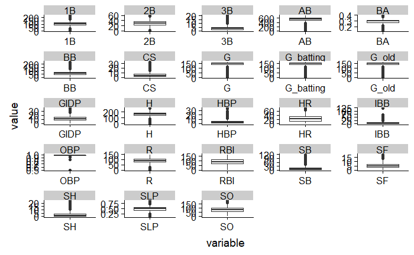

```r
# Creating a Data Farme to Plot All Numrical Vaibles at Once
  plot.table <- baseball[, c(5:23, 27:30)] %>% gather(key = "variable", value = "value")
# Plot
  ggplot(data = plot.table, aes(x=variable, y=value)) + geom_boxplot() +
    facet_wrap( ~ variable, scales="free")
```

What if we just look at the [current era](https://www.huffingtonpost.com/quora/what-are-the-major-eras-o_b_3547814.html) of baseball

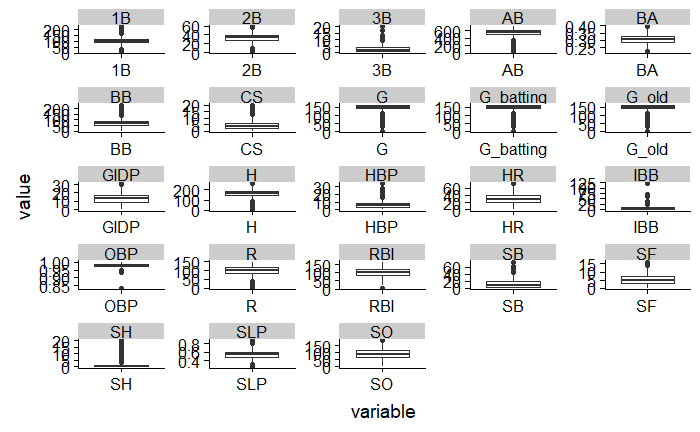

We get a few less outliers, for some varibles but more for others, but nothing of to much note.

As some varibels have many outliers will just remove outliers for varibels that have few outliers

**note:** Using all era data frame agian.

[output not shown]